[GitHub](https://github.com/JuliaGeometry/DelaunayTriangulation.jl)[](https://github.com/JuliaGeometry/DelaunayTriangulation.jl/tree/main/docs/src/literate_tutorials/constrained_outer_boundary_segmented.jl)

# Constrained Triangulations

## Sectioned Outer Boundary

In this tutorial, we again consider a triangulation with a constrained boundary. In contrast to the previous tutorial, this outer boundary will be represented as a chain of multiple paths or sections. This changes nothing geometrically, but it allows for the identification of separate parts of a boundary. This is useful, for example, if you want to assign different boundary conditions on different parts of the boundary for a differential equation problem. To start, let us load in the packages we will need.

```julia
using DelaunayTriangulation
using CairoMakie
```

Now, we define some of the points we will be triangulating.

```julia
points = [
    (2.0, 8.0), (6.0, 4.0), (2.0, 6.0),
    (2.0, 4.0), (8.0, 2.0)
]
```

```
5-element Vector{Tuple{Float64, Float64}}:
 (2.0, 8.0)
 (6.0, 4.0)
 (2.0, 6.0)
 (2.0, 4.0)
 (8.0, 2.0)
```

```julia
section_1 = [(0.0, 0.0), (14.0, 0.0)]
section_2 = [(14.0, 0.0), (10.0, 4.0), (4.0, 6.0), (2.0, 12.0), (0.0, 14.0)]
section_3 = [(0.0, 14.0), (0.0, 0.0)]
boundary_points = [section_1, section_2, section_3]
```

```
3-element Vector{Vector{Tuple{Float64, Float64}}}:
 [(0.0, 0.0), (14.0, 0.0)]
 [(14.0, 0.0), (10.0, 4.0), (4.0, 6.0), (2.0, 12.0), (0.0, 14.0)]
 [(0.0, 14.0), (0.0, 0.0)]
```

We now convert these boundary points to indices using `convert_boundary_points_to_indices`, and then we triangulate. We also add a constrained edge.

```julia
E = Set(((6, 9),)) # (0, 0) → (4, 6)
boundary_nodes, points = convert_boundary_points_to_indices(boundary_points; existing_points=points)
tri = triangulate(points; boundary_nodes, segments=E)
```

```
Delaunay Triangulation.
   Number of vertices: 11
   Number of triangles: 14
   Number of edges: 24
   Has boundary nodes: true
   Has ghost triangles: true
   Curve-bounded: false
   Weighted: false
   Constrained: true
```

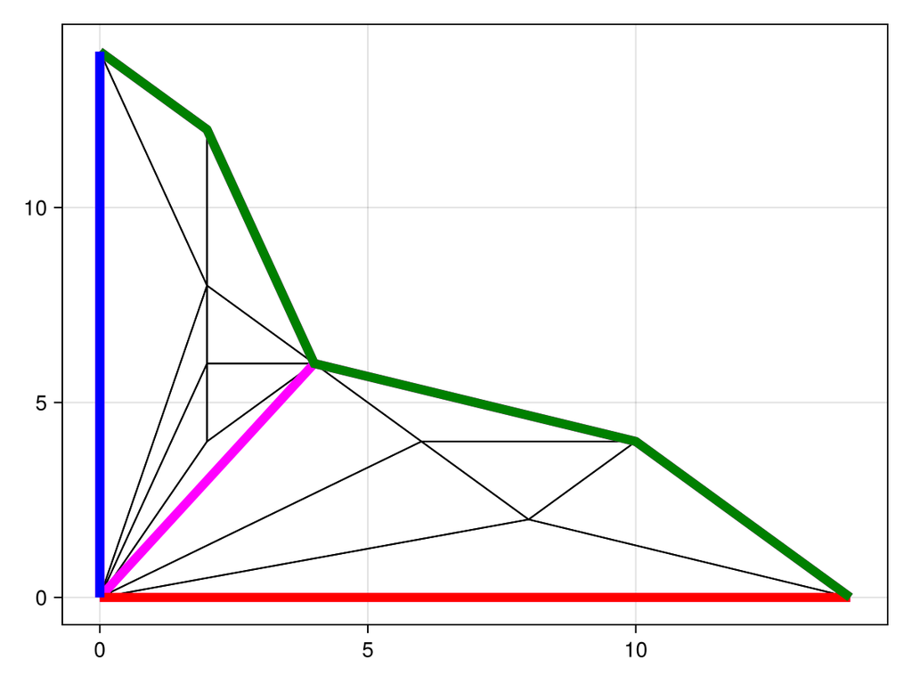

```julia
fig, ax, sc = triplot(tri, show_constrained_edges=true, constrained_edge_linewidth=6)
lines!(ax, section_1, color=:red, linewidth=6)
lines!(ax, section_2, color=:green, linewidth=6)
lines!(ax, section_3, color=:blue, linewidth=6)
fig
```

The first section is in red, the second section is in green, and the third section is in blue. We use ghost vertices to identify the sections, where the first section is identified by `-1`, the second by `-2`, and the third by `-3`.

Before we go into how the sections can be worked with, let us make a note regarding `get_interior_segments(tri)`, now that we have both constrained segments and boundary segments which might technically both be thought of as being constrained edges. If we look at `get_interior_segments(tri)`, we get:

```julia
get_interior_segments(tri)
```

```
Set{Tuple{Int64, Int64}} with 1 element:
  (9, 6)
```

This is just the constrained segment we provided, and not the boundary segment. If we instead want all constrained segments, considering both the boundary segments and the segments provided, we can instead use `get_all_segments(tri)`.

```julia
get_all_segments(tri)
```

```
Set{Tuple{Int64, Int64}} with 7 elements:
  (9, 6)
  (7, 8)
  (8, 9)
  (9, 10)
  (6, 7)
  (10, 11)
  (11, 6)
```

Let us now explore the several ways available for working with this boundary. First, if we just want to work with the boundary edges without caring about the order, we can again use the boundary edge map.

```julia
get_boundary_edge_map(tri)
```

```
Dict{Tuple{Int64, Int64}, Tuple{Int64, Int64}} with 6 entries:
  (7, 8) => (2, 1)
  (8, 9) => (2, 2)
  (9, 10) => (2, 3)
  (6, 7) => (1, 1)
  (10, 11) => (2, 4)
  (11, 6) => (3, 1)
```

Remember that the keys are the edges, and the values are `Tuples` that give us (1) the section index, and (2) the position of the edge within that section (more specifically, the position of the first vertex of the edge). This would be useful if, for example, you don't care about the order of the edges, but you do care about what section the edge belongs to so that you can assign a boundary condition for example. In the previous tutorial, we mentioned that the `Tuples` are of the form `(I, J)` so that the corresponding edge is identified from `get_boundary_nodes(get_boundary_nodes(tri, I), J)`, but since both `I` and `J` are integers in this case (since we have sections), we can just use `get_boundary_nodes(tri, (I, J))`. (The former form is still the most general to support the case of a single boundary.) Here is an example of using this map to compute the sum

\[S = \sum_{(i, j) \in \mathcal E} f\left(\frac{x_i+x_j}{2}, \frac{y_i+y_j}{2}\right),\]

where $\mathcal E$ are the set of boundary edges, and

\[f(x, y) = \begin{cases} 1 & (x, y) \in \Gamma_1, \\ \sin(x - y) & (x, y) \in \Gamma_2, \\ \cos(x + y) & (x, y) \in \Gamma_3, \end{cases}\]

and $\Gamma_i$ denotes the $i$th section.

```julia
function section_function(x, y, section_index)
    f = if abs(section_index) == 1
        1.0
    elseif abs(section_index) == 2
        sin(x - y)
    else
        cos(x + y)
    end
    return f
end
function compute_sum(tri)
    bem = get_boundary_edge_map(tri)
    s = 0.0
    for (e, (section_index, _)) in bem
        u, v = edge_vertices(e)
        p, q = get_point(tri, u, v)
        px, py = getxy(p)
        qx, qy = getxy(q)
        mx, my = (px + qx) / 2, (py + qy) / 2
        s += section_function(mx, my, section_index)
    end
    return s
end
s = compute_sum(tri)
```

```
2.9351669864789773
```

An alternative way to look at each section is to use `get_adjacent2vertex` with the associated ghost vertex.

```julia
get_adjacent2vertex(tri, -1)
```

```
Set{Tuple{Int64, Int64}} with 1 element:
  (7, 6)
```

```julia
get_adjacent2vertex(tri, -2)
```

```
Set{Tuple{Int64, Int64}} with 4 elements:
  (10, 9)
  (8, 7)
  (11, 10)
  (9, 8)
```

```julia
get_adjacent2vertex(tri, -3)
```

```
Set{Tuple{Int64, Int64}} with 1 element:
  (6, 11)
```

Note that the provided edges are not in order, but this is helpful for considering specific sections. For example, if we just wanted to compute the above sum over the second section, we could do

```julia
function compute_sum_2(tri)
    edges = get_adjacent2vertex(tri, -2)
    s = 0.0
    for e in edges
        u, v = edge_vertices(e)
        p, q = get_point(tri, u, v)
        px, py = getxy(p)
        qx, qy = getxy(q)
        mx, my = (px + qx) / 2, (py + qy) / 2
        s += section_function(mx, my, -2)
    end
    return s
end
s = compute_sum_2(tri)
```

```
1.1812647321356726
```

If your application instead wanted all the nodes on the section rather than the edges, you can look at the neighbours to the ghost vertex. For example, all the nodes on the section section can be identified using

```julia
get_neighbours(tri, -2)
```

```
Set{Int64} with 5 elements:
  7
  11
  10
  9
  8
```

Another field is the `ghost_vertex_map`, which maps a given ghost vertex to the associated section. This is more so useful for internal methods, but you may sometimes need it.

```julia
get_ghost_vertex_map(tri)
```

```
Dict{Int64, Int64} with 3 entries:
  -1 => 1
  -3 => 3
  -2 => 2
```

In this case, the `i`th section just has the ghost vertex `-i`, but this is typically used to deal with the case of multiple boundaries so that we know where a ghost vertex belongs.

## Just the code

An uncommented version of this example is given below. You can view the source code for this file [here](https://github.com/JuliaGeometry/DelaunayTriangulation.jl/tree/main/docs/src/literate_tutorials/constrained_outer_boundary_segmented.jl).

```julia
using DelaunayTriangulation
using CairoMakie

points = [
    (2.0, 8.0), (6.0, 4.0), (2.0, 6.0),
    (2.0, 4.0), (8.0, 2.0)
]

section_1 = [(0.0, 0.0), (14.0, 0.0)]
section_2 = [(14.0, 0.0), (10.0, 4.0), (4.0, 6.0), (2.0, 12.0), (0.0, 14.0)]
section_3 = [(0.0, 14.0), (0.0, 0.0)]
boundary_points = [section_1, section_2, section_3]

E = Set(((6, 9),)) # (0, 0) → (4, 6)
boundary_nodes, points = convert_boundary_points_to_indices(boundary_points; existing_points=points)
tri = triangulate(points; boundary_nodes, segments=E)

fig, ax, sc = triplot(tri, show_constrained_edges=true, constrained_edge_linewidth=6)
lines!(ax, section_1, color=:red, linewidth=6)
lines!(ax, section_2, color=:green, linewidth=6)
lines!(ax, section_3, color=:blue, linewidth=6)
fig

get_interior_segments(tri)

get_all_segments(tri)

get_boundary_edge_map(tri)

function section_function(x, y, section_index)
    f = if abs(section_index) == 1
        1.0
    elseif abs(section_index) == 2
        sin(x - y)
    else
        cos(x + y)
    end
    return f
end
function compute_sum(tri)
    bem = get_boundary_edge_map(tri)
    s = 0.0
    for (e, (section_index, _)) in bem
        u, v = edge_vertices(e)
        p, q = get_point(tri, u, v)
        px, py = getxy(p)
        qx, qy = getxy(q)
        mx, my = (px + qx) / 2, (py + qy) / 2
        s += section_function(mx, my, section_index)
    end
    return s
end
s = compute_sum(tri)

get_adjacent2vertex(tri, -1)

get_adjacent2vertex(tri, -2)

get_adjacent2vertex(tri, -3)

function compute_sum_2(tri)
    edges = get_adjacent2vertex(tri, -2)
    s = 0.0
    for e in edges
        u, v = edge_vertices(e)
        p, q = get_point(tri, u, v)
        px, py = getxy(p)
        qx, qy = getxy(q)
        mx, my = (px + qx) / 2, (py + qy) / 2
        s += section_function(mx, my, -2)
    end
    return s
end
s = compute_sum_2(tri)

get_neighbours(tri, -2)

get_ghost_vertex_map(tri)
```

*This page was generated using Literate.jl.*